# STAT 545: Homework 3

Ken Lau

Saturday, September 27, 2014

### Import Data

```r
gd_url <- "http://www.stat.ubc.ca/~jenny/notOcto/STAT545A/examples/gapminder/data/gapminderDataFiveYear.txt"
gtbl <- gd_url %>% read.delim %>% tbl_df
gtbl %>% glimpse
```

```
## Variables:
## $ country   (fctr) Afghanistan, Afghanistan, Afghanistan, Afghanistan,...
## $ year      (int) 1952, 1957, 1962, 1967, 1972, 1977, 1982, 1987, 1992...
## $ pop       (dbl) 8425333, 9240934, 10267083, 11537966, 13079460, 1488...
## $ continent (fctr) Asia, Asia, Asia, Asia, Asia, Asia, Asia, Asia, Asi...
## $ lifeExp   (dbl) 28.80, 30.33, 32.00, 34.02, 36.09, 38.44, 39.85, 40....
## $ gdpPercap (dbl) 779.4, 820.9, 853.1, 836.2, 740.0, 786.1, 978.0, 852...
```

### Task 1

```r
out = gtbl %>%
        group_by(continent) %>%
        summarise(meanGdpPerCap = mean(gdpPercap))
```

```r
print(xtable(out), comment=F, type="html", include.rownames=F)
```

| continent | meanGdpPerCap |
| --- | --- |
| Africa | 2193.75 |
| Americas | 7136.11 |
| Asia | 7902.15 |
| Europe | 14469.48 |
| Oceania | 18621.61 |

I decided not to make a plot here as the table summarizes things quite clearly. Also, xtable is not bad for a naive approach to displaying tables.

### Task 2

Determine spread of GDP per capita within the continents.

**Note: It may show up blank first. Adjust size by pressing bottom right corner of plot and it’ll show up.**

```r
gtbl %>% ggvis(x=~gdpPercap, stroke=~continent) %>%
  group_by(continent) %>%
  layer_densities(area=F, strokeWidth:=2) %>%
  add_axis("y", title="density", title_offset=70)
```

[output not shown]

This plot is done by ggvis. We can see that Oceania’s distribution of gdp per capita is higher overall than the other continents. Asia has a few countries with an extreme maximum. Also, Africa’s gdp per capita is skewed with many countries with low gdp per capita, while fewer numbers with high gdp per capita.

### Task 3

We will aggregate life expectancy based on mean for each year. Then we will calculate the weighted mean of life expectancy using population for each year.

| year | meanLifeExp | weightedMeanLifeExp |
| --- | --- | --- |
| 1952 | 49.06 | 48.94 |
| 1957 | 51.51 | 52.12 |
| 1962 | 53.61 | 52.32 |
| 1967 | 55.68 | 56.98 |
| 1972 | 57.65 | 59.51 |
| 1977 | 59.57 | 61.24 |
| 1982 | 61.53 | 62.88 |
| 1987 | 63.21 | 64.42 |
| 1992 | 64.16 | 65.65 |
| 1997 | 65.01 | 66.85 |
| 2002 | 65.69 | 67.84 |
| 2007 | 67.01 | 68.92 |

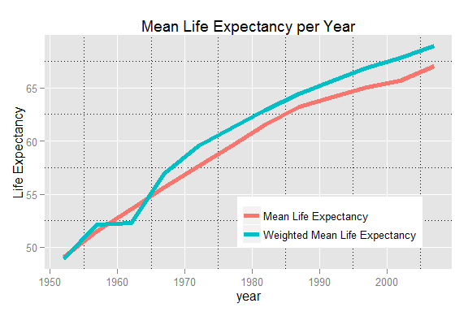

```r
out = gtbl %>% group_by(year) %>%
        mutate(weightPop=pop/sum(pop)) %>%
        summarise(meanLifeExp=mean(lifeExp),
          weightedMeanLifeExp=weighted.mean(lifeExp,w=weightPop))
outLong = out %>%
            melt(id.vars="year", measures.vars=c("meanLifeExp",
              "weightedMeanLifeExp"), variable.name="meanType",
              value.name="lifeExp")
#scale_colour_discrete allows us to modify the names in legends
#theme can help change position of legend
gg = ggplot(outLong, aes(x=year, y=lifeExp)) +
      geom_line(aes(colour=meanType), size=2) +
      ylab("Life Expectancy") +
      ggtitle("Mean Life Expectancy per Year") +
      scale_colour_discrete(labels=c("Mean Life Expectancy",
                                  "Weighted Mean Life Expectancy")) +
      guides(colour=guide_legend(title=NULL)) +
      theme(legend.position=c(.7,.2)) +
      theme(panel.grid.minor=element_line(colour="black",
                                          linetype = "dotted"))
```

I generated the two-column display above with the help of a [stack overflow answer](http://stackoverflow.com/questions/19237190/2-column-report-in-r-markdown-render-html-aside-data-frame).

### Task 4

Here we determine the relative abundance of countries with life expectancy in percent less than 40 by years for each continent.

```r
out = gtbl %>% group_by(continent, year) %>%
        mutate(lowExp=lifeExp < 40) %>%
        summarise(relLowExp=mean(lowExp)*100)
outTable = dcast(out, year ~ continent, value.var="relLowExp")
mp = mPlot(x="year", y=names(outTable %>% select(-year)), data=outTable,
      type="Line")
```

[interactive chart not shown]

This is from rCharts. Sorry I couldn’t figure out how to add titles, axis, and good formating in general. The y-axis represents the % of countries for a particular continent with life expectancy lower than 40. The x-axis is the year.

### IPython Notebook

Please see find the notebook from homeowork3’s README.md file. It continues analysis of this dataset.

### Report of process

dplyr was definitely a great experience. I’ve used plyr a lot back then, but dplyr makes the code much cleaner. I realized there is a function do() as part of dplyr which will make it generalize well for any task. rCharts was quite a pain to render to html, but it works now.